# Praca Domowa 6

Autor: Paulina Przybyłek

## Wczytanie danych i odpowiednich pakietów

```python
import numpy as np
import pandas as pd
import matplotlib.pyplot as plt
from sklearn.cluster import MiniBatchKMeans
from sklearn.mixture import GaussianMixture
from sklearn.metrics import davies_bouldin_score, silhouette_score, calinski_harabasz_score
from sklearn import preprocessing
import warnings
warnings.filterwarnings('ignore')
np.random.seed(123)
```

Zadanie polega na porównaniu 2 metod klasteryzujących i porównaniu wyników wybranych metod przy pomocy przynajmniej 2 metryk oceny klasteryzacji. Dane wykorzystywane do zadania wczytujemy z pliku `clustering_R3.csv`, które są przedstawione w wymiarze $\mathbb{R}^3$.

```python
data = pd.read_csv('../../clustering_R3.csv')
```

```python
data.head()
```

|  | X1 | X2 | X3 |
| --- | --- | --- | --- |
| 0 | 152.077986 | 197.910402 | 1.095707 |
| 1 | 145.520487 | 202.128032 | 2.738826 |
| 2 | 155.441273 | 198.122696 | 0.640457 |
| 3 | 150.389105 | 206.808383 | 0.686486 |
| 4 | 149.863221 | 205.417527 | 3.555814 |

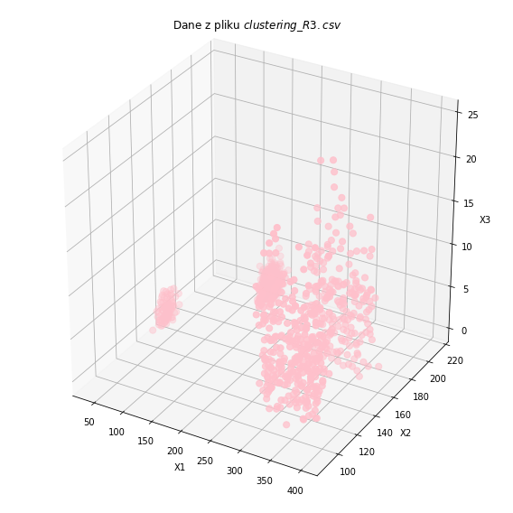

```python
fig = plt.figure(figsize=(8, 8))
ax = fig.add_subplot(111, projection='3d')

ax.scatter(data.X1, data.X2, data.X3, s=50, color = 'pink')

ax.set_xlabel('X1')
ax.set_ylabel('X2')
ax.set_zlabel('X3')
ax.set_title('Dane z pliku $clustering\_R3.csv$', pad = 20)

plt.tight_layout()
plt.show()
```

Na powyższym wykresie możemy zaobserwować nasze dane. Przedstawione są w postaci 3D i nie widzimy w jaki sposób mogą zostać podzielone (na ile skupisk). Na pewno mamy co najmniej 2 klastry, widząc oddalone od siebie skupiska punktów. ZObaczmy ile jest iptymalnie przy użyciu wybranych metod klasteryzujących i metryk.

Zanim przejdziemy dalej dokonajmy standaryzacji naszych danych.

```python
std_scaler = preprocessing.StandardScaler().fit(data.iloc[:,[0,1,2]])
data_std = pd.DataFrame(std_scaler.transform(data.iloc[:,[0,1,2]]), columns=["X1", "X2", "X3"])
data_std.head()
```

|  | X1 | X2 | X3 |
| --- | --- | --- | --- |
| 0 | -0.762807 | 1.024554 | -0.909772 |
| 1 | -0.819582 | 1.125110 | -0.566853 |
| 2 | -0.733687 | 1.029615 | -1.004782 |
| 3 | -0.777429 | 1.236698 | -0.995176 |
| 4 | -0.781982 | 1.203537 | -0.396348 |

## Metody klasteryzujące

- indeksu Daviesa–Bouldina
- metody Silhouette
- indeksu Calińskiego-Harabasza

Postaramy się stosować domyślne implementacje metod. Zdefiniujmy również **funkcje pomocnicze**:

```python
def plot_model_clusters(X, model, title=""):
    """
    Funckja przyjmuje dane X punktów, nazwę modelu, tytuł wykresu i liczbę klastrów.
    Zwraca wykres dla danej metody podziału na odpowiednią ilość skupisk.
    """
    if hasattr(model, 'labels_'):
        y_model = model.labels_.astype(np.int)
    else:
        y_model = model.predict(X)

    fig = plt.figure(figsize=(8, 8))
    ax = fig.add_subplot(111, projection='3d')

    ax.scatter(data.X1, data.X2, data.X3, s=50, c=y_model, cmap='plasma')

    ax.set_xlabel('X1')
    ax.set_ylabel('X2')
    ax.set_zlabel('X3')
    ax.set_title(title, pad = 20)

    plt.tight_layout()
    plt.show()
```

```python
def count_clustering_scores_MiniBatch(X, cluster_num, model, score_fun):
    """
    Dla podanych danych, modelu i zakresu klastrów zwraca wektor wyników podanej metryki.
    """
    if isinstance(cluster_num, int):
        cluster_num_iter = [cluster_num]
    else:
        cluster_num_iter = cluster_num

    scores = []
    for k in cluster_num_iter:
        model_instance = model(n_clusters=k)
        labels = model_instance.fit_predict(X)
        wcss = score_fun(X, labels)
        scores.append(wcss)

    if isinstance(cluster_num, int):
        return scores[0]
    else:
        return scores
```

```python
def count_clustering_scores_GMM(X, n_components, model, covariance_type, score_fun):
    """
    Dla podanych danych, modelu i zakresu klastrów zwraca wektor wyników podanej metryki.
    """
    if isinstance(n_components, int):
        n_components_iter = [n_components]
    else:
        n_components_iter = n_components

    scores = []
    for k in n_components_iter:
        model_instance = model(n_components=k, covariance_type=covariance_type)
        labels = model_instance.fit_predict(X)
        wcss = score_fun(X, labels)
        scores.append(wcss)

    if isinstance(n_components, int):
        return scores[0]
    else:
        return scores
```

```python
def plot_cluster_metrics(cluster_num_seq, score_vec, y_title_score, title):
    """
    Rysuje wykres metryki - podajemy wektor klastrów i wektor miar im odpowiadających oraz tytuł osi Y.
    """
    plt.plot(cluster_num_seq, score_vec, 'bx-')
    plt.xlabel('Liczba klastrów')
    plt.ylabel(y_title_score)
    plt.title(title)
    plt.show()
```

### Opis stosowanych metryk oceny klasteryzacji

*Metoda Silhouette*

Metoda silhouette została opisana na zajęciach. Przpomnijmy któtko jak wygląda: $$ a(i) := \frac{1}{\# C(i) -1 } \sum_{j \in C(i), i \neq j} d(i, j)$$ $$ b(i) := \underset{k: C_k \bigcap C(i) = \emptyset}{min} \frac{1}{\# C_k} \sum_{j \in C_k} d(i, j) $$ Gdzie:
$i$ — indeks punktu,
$C(i)$ — klaster, do którego należy $i$-ty punkt,
$d(i, j)$ — odległość między $i$-tym i $j$-tym punktem, $C_k$ - $k$-ty klaster.

Liczbę $a$ możemy interpretować jako średnią odległość od punktu w tym samym klastrze. Natomiast liczba $b$ to po prostu średnia odległość od punktów tego klastra, który jest „drugim najlepszym” dla $i$-tego punktu.

Ostatecznie miara silhouette wygląda tak: $$ S(n)=\frac{\sum_{i=1}^{n}\frac{b(i) - a(i)}{\max{ \{ a(i), b(i) \} }}}{n} $$

Oczywiście $n$ to liczba wszystkich punktów a formuła pod sumą mówi nam o tym, jak dobrze dany punkt pasuje do klastra, do którego został przyporządkowany w porównaniu z tym klastrem, który jest „drugim wyborem".

*Indeks Daviesa–Bouldina*

$$ DB(n)=\frac{1}{n}\sum_{i=1}^{n}( \underset{j=1,\ldots,n \wedge i \ne j}{max}{\frac{w_i+w_j}{D(C_i,C_j)}}) $$

$D(C_i,C_j)$ jest miarą odległości między grupami $C_i$ oraz $C_j$, natomiast $w_i$: dla $i=1,\ldots,n$ oznaczają wagi grup. Indeks polega na wyliczeniu średniej wartości podobieństwa między grupami. Oczekuje się, by podobieństwo między grupami było jak najmniejsze dlatego optymalna liczba grup minimalizuje powyższy indeks.

*Indeks Calińskiego-Harabasza*

Jest on znany jako kryterium współczynnika wariancji. Wynik jest zdefiniowany jako stosunek między dyspersją wewnątrz klastra i dyspersją między klastrami.

$$ CH(i)=\frac{tr(B_i)/(i - 1)}{tr(W_i)/(n - i)} $$

Gdzie:  
$tr(B_i)$ — macierz kowariancji międzygrupowej,  
$tr(W_i)$ — macierz kowariancji wewnątrzgrupowej,  
$n$ — liczba punktów w zbiorze.

Za wybraną liczbę skupień należy uznać liczbę $i$, która daje maksymalną wartość wyrażenia $CH(i)$.

### Metoda Mini Batch

```python
def _MiniBatchKMeans(X, n_clusters):
    """
    Funkcja przyjmuje zbiór i liczbę klastrów oraz trenuje model Mini Batch.
    """
    miniBatchKmeans = MiniBatchKMeans(n_clusters=n_clusters)
    miniBatchKmeans.fit(X)
    return X, miniBatchKmeans
```

Zacznijmy od znalezienia optymalnej liczby klastrów przy wykorzystaniu naszych metryk. Dla kazdej z trzech metod sprawdzimy zakres klastrów od 2 do 14.

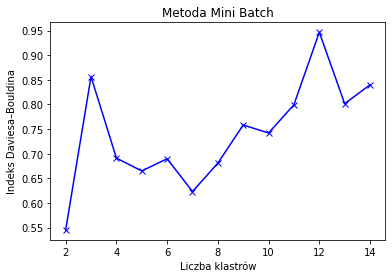

```python
cluster_num_seq = range(2, 15)
davies_bouldin_vec = count_clustering_scores_MiniBatch(data_std, cluster_num_seq, MiniBatchKMeans,
                                                       davies_bouldin_score)
plot_cluster_metrics(cluster_num_seq, davies_bouldin_vec, 'Indeks Daviesa–Bouldina', 'Metoda Mini Batch')
```

Indeks Daviesa–Bouldina zwraca wartości liczbowe, gdzie najlepszym wynikiem jest 0. Oznacza to, że im bliższy zera wynik tym ta liczba klastrów jest bardziej optymalna.

W naszym przypadku najlepszy wynik mamy dla 2 klastów (to pewnie ten widoczny podział na wykresie 3D zbioru, o którym mówiliśmy na początku) a potem dla 7 klastrów. Sprawdzimy oba przypadki, gdyż podział na dwa uważam za niekoniecznie dobry wybór.

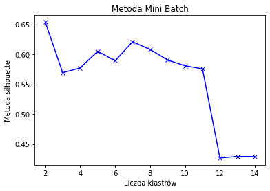

```python
silhouette_vec = count_clustering_scores_MiniBatch(data_std, cluster_num_seq, MiniBatchKMeans, silhouette_score)
plot_cluster_metrics(cluster_num_seq, silhouette_vec, 'Metoda silhouette', 'Metoda Mini Batch')
```

W przypadku metody Silhouette chcemy wybrać liczbę klastrów, która osiąga najwyższy wynik.

Można zauważyć, że takie same wyniki jak wcześniej - najlepszy okazuje się podział na 2 skupiska, a drugi najlepszy to 7.

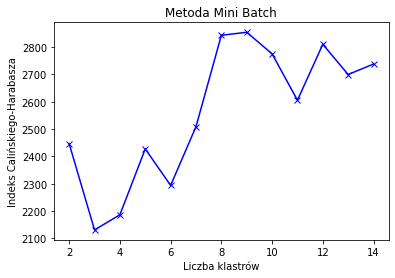

```python
calinski_harabasz_vec = count_clustering_scores_MiniBatch(data_std, cluster_num_seq, MiniBatchKMeans,
                                                          calinski_harabasz_score)
plot_cluster_metrics(cluster_num_seq, calinski_harabasz_vec, 'Indeks Calińskiego-Harabasza', 'Metoda Mini Batch')
```

Indeks Calińskiego-Harabasza także chcemy zmaksymalizować - osiągamy to dla 9 klastrów (drugim podziałem tylko delikatnie gorszym jest 8). Czyli tutaj mamy kompletnie inne wyniki niż poprzednio. Dodatkowo, patrząc na 2 i 7, najlepsze wybory wedle poprzednich metryk, to są one dość nisko usytuowane na wykresie.

Narysujmy teraz nasze podziały i zobaczmy, który byłby rzeczywiście najlepszy.

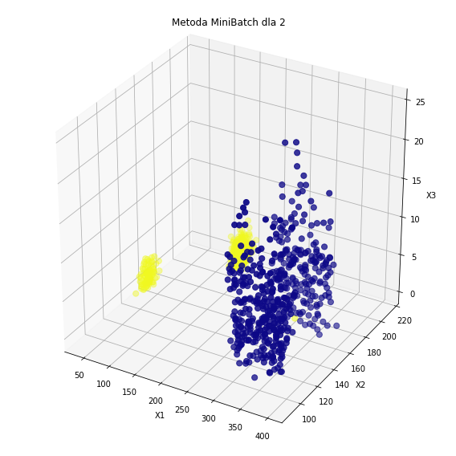

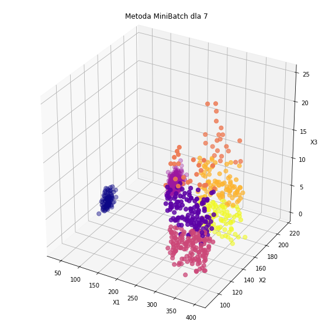

```python
plot_model_clusters(*_MiniBatchKMeans(data_std, n_clusters=2), title='Metoda MiniBatch dla 2')
plot_model_clusters(*_MiniBatchKMeans(data_std, n_clusters=7), title='Metoda MiniBatch dla 7')
```

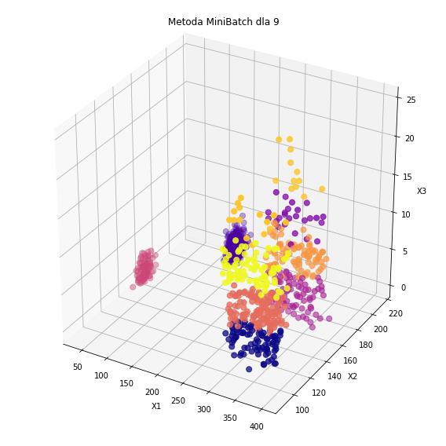

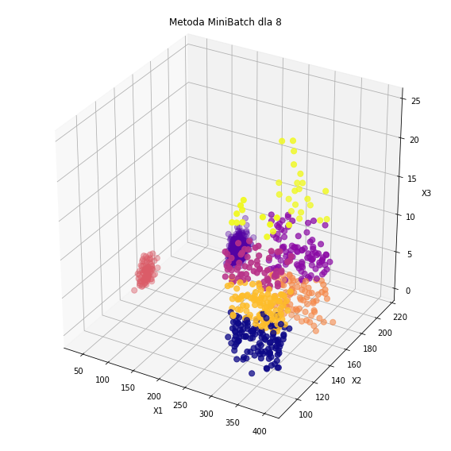

```python
plot_model_clusters(*_MiniBatchKMeans(data_std, n_clusters=9), title='Metoda MiniBatch dla 9')
plot_model_clusters(*_MiniBatchKMeans(data_std, n_clusters=8), title='Metoda MiniBatch dla 8')
```

Moim zdaniem najlepiej wygląda podział na 9 skupisk, chociaż podział na 7 i 8 nie jest zły. Niektórym mógłby spodobać się bardziej np. podział na 7, bo jest mniej skupisk a też ładnie się rozkładają, jednak ja skłaniam się do wyboru większej liczby podziału. Wydaje mi się, że jako metoda oceny sprawdził się lepiej Indeks Calińskiego-Harabasza, gdyż jego podziały są całkiem dobre. Natomiast Indeks Daviesa-Bouldina oraz Metoda Silhouette wybrały za najlepszy podział na 2, który nie wygląda najlepiej.

### Metoda Gaussian Mixture (GMM)

```python
def _GMM(X, n_components, covariance_type='full'):
    """
    Funkcja przyjmuje zbiór i liczbę klastrów oraz trenuje model .
    """
    gmm = GaussianMixture(n_components=n_components, covariance_type=covariance_type)
    gmm.fit(X)
    return X, gmm
```

Jak poprzednio zaczniemy od sprawdzenia metryk i wyboru optymalnej liczby klastrów.

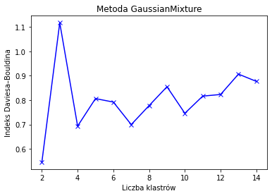

```python
components_num_seq = range(2, 15)
davies_bouldin_vec = count_clustering_scores_GMM(data_std, components_num_seq, GaussianMixture,
                                                 'full', davies_bouldin_score)
plot_cluster_metrics(components_num_seq, davies_bouldin_vec, 'Indeks Daviesa–Bouldina', 'Metoda GaussianMixture')
```

Najlepsze (najniższe wyniki na wykresie) uzyskało 2, a na drugim miejscu znajduje się 4. Ponownie sprawdzimy oba wybory.

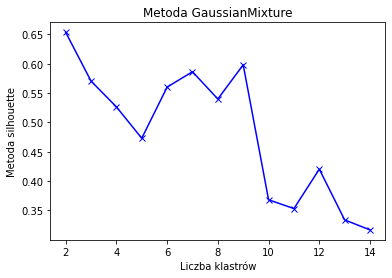

```python
silhouette_vec = count_clustering_scores_GMM(data_std, components_num_seq, GaussianMixture,
                                             'full', silhouette_score)
plot_cluster_metrics(components_num_seq, silhouette_vec, 'Metoda silhouette', 'Metoda GaussianMixture')
```

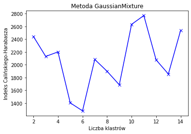

```python
calinski_harabasz_vec = count_clustering_scores_GMM(data_std, components_num_seq, GaussianMixture,
                                                    'full', calinski_harabasz_score)
plot_cluster_metrics(cluster_num_seq, calinski_harabasz_vec,
                     'Indeks Calińskiego-Harabasza', 'Metoda GaussianMixture')
```

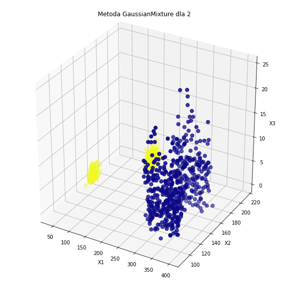

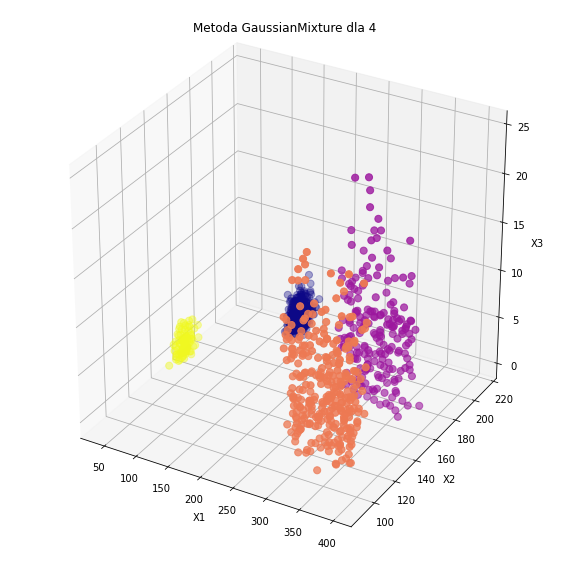

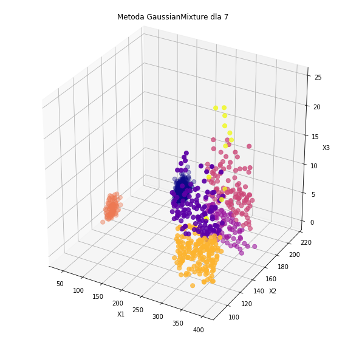

```python
plot_model_clusters(*_GMM(data_std, n_components=2), title='Metoda GaussianMixture dla 2')
plot_model_clusters(*_GMM(data_std, n_components=4), title='Metoda GaussianMixture dla 4')
plot_model_clusters(*_GMM(data_std, n_components=7), title='Metoda GaussianMixture dla 7')
```

Wybierając z tych trzech to najlepiej wypadł podział na 4 wedle mojej opinii.

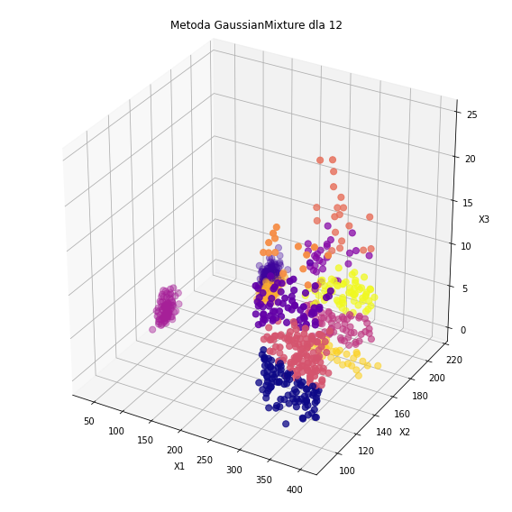

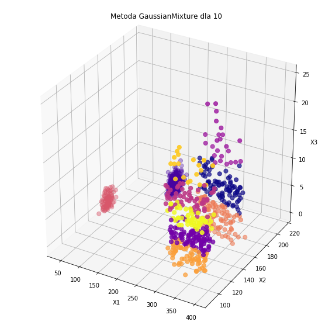

```python
plot_model_clusters(*_GMM(data_std, n_components=12), title='Metoda GaussianMixture dla 12')
plot_model_clusters(*_GMM(data_std, n_components=10), title='Metoda GaussianMixture dla 10')
```

Porównajmy teraz obie metryki, ich podziały optymalne i czas. Przyjrzyjmy się czasowi wykonania MiniBatch dla 9 klastrów, a GaussianMixture dla 10. Chociaż po wiadomości z dzisiaj (2.06) nie wiem na ile można wierzyć tym wynikom, jednak jest to w celach porównania z drugą metodą przy podobnej pracy komputera (mam nadzieję).

```python
%%time
batch_kmeans=_MiniBatchKMeans(data_std, n_clusters=9)
```

```
CPU times: user 1.77 s, sys: 8.44 ms, total: 1.78 s
Wall time: 255 ms
```

```python
%%time
gmm=_GMM(data_std, n_components=10)
```

```
CPU times: user 1.29 s, sys: 7.08 ms, total: 1.3 s
Wall time: 197 ms
```

Wyniki w zależności od momentu wywołania zmieniają się i jednak nie da się tego ocenić. Jednak jedna i druga metoda działają stosunkowo szybko.

Porównując natomiast zwracane podziały to również trudno zdecydować, który jest najlepszy. Wedle Indeksu CH to podział na 9 uzyskał więcej na Osi Y, więc może warto by zastosować ten, skoro nie jest łątwo wybrać po spojrzeniu na wykresy.